# OMSBA 5300 Data Exploration Project

Raymond Chen

2/16/2021

## Libraries

```r
# Loading necessary libraries
library(tidyverse)
library(jtools)
library(vtable)
library(car)
library(estimatr)
library(lubridate)
library(readr)
library(ggplot2)
library(ggpubr)
```

## Load data

```r
# Set default working directory
setwd("/Users/cray/Desktop/OMSBA5300/DEP/OMSBA5300_DEP")

# Set file directory for data
dep_dir <- 'Data'
dep_files <- list.files(path = dep_dir, pattern = '*.csv', full.names=TRUE)

# Combine trends csvs into a dataframe
trends_dir <- 'Data/Trends'
trends_df <- list.files(path=trends_dir, pattern="*.csv", full.names=TRUE) %>%
  lapply(read_csv) %>%
  bind_rows()

# Turn other csvs into dataframe for processing later
id_name_link <- read_csv(file = 'Data/id_name_link.csv')
scorecard <- read_csv(file = 'Data/Most+Recent+Cohorts+(Scorecard+Elements).csv')
```

## Clean up data

Assumptions:

- Schools with the same school name are considered duplicated and removed from the dataframe
- Schools with missing data (NAs) are removed from the dataframe
- Indexes are standardized among the keywords
- High/Low reported earning schools are divided by the median of “Median earnings of students working and not enrolled 10 years after entry”
- Schools that do not report such earnings are removed from the dataframe

```r
# Check for schools with same names and remove them from dataframe
dups <- data.frame(table(id_name_link$schname)) %>%
  rename(schname = Var1) %>%
  filter(Freq > 1)

id_name_link <- id_name_link %>%
  anti_join(dups, by = 'schname')

# Join schools id with trends and create a standardized index score
trends_w_id <- trends_df %>%
  left_join(id_name_link) %>%
  na.omit() %>%
  group_by(keyword) %>%
  mutate(index_std = (index - mean(index)) / sd(index))

# Replace the '-' in the scorecard's variables with '_'
names(scorecard) <- gsub(x = names(scorecard), pattern = '-', replacement = '_')

# Filter out schools predominantly grant bachelor's degrees and capture the earnings
ba_school_trends <- scorecard %>%
  filter(PREDDEG == 3) %>%
  select(UNITID, OPEID, STABBR, md_earn_wne_p10_REPORTED_EARNINGS) %>%
  rename(unitid = UNITID, opeid = OPEID, state = STABBR, earnings = md_earn_wne_p10_REPORTED_EARNINGS) %>%
  inner_join(trends_w_id, by = c('opeid', 'unitid'))

# Convert earnings to numeric
ba_school_trends$earnings <- as.numeric(ba_school_trends$earnings)

# Define High/Low earning schools
ba_school_trends <- ba_school_trends %>%
  na.omit() %>%
  mutate(earning_lvl = ifelse(earnings >= median(earnings), 'HIGH', 'LOW'))

# View data before exploration
vtable(ba_school_trends)
```

ba_school_trends

| Name | Class | Values |
| --- | --- | --- |
| unitid | numeric | Num: 100654 to 475273 |
| opeid | numeric | Num: 100200 to 82098821 |
| state | character |  |
| earnings | numeric | Num: 16700 to 166200 |
| schid | numeric | Num: 0 to 12082 |
| schname | character |  |
| keyword | character |  |
| keynum | numeric | Num: 1 to 9 |
| monthorweek | character |  |
| index | numeric | Num: 0 to 100 |
| index_std | numeric | Num: -4.741 to 12.361 |
| earning_lvl | character |  |

## Data Exploration

```r
# Build dataframe for exploration
weekly_trend <- ba_school_trends %>%
  group_by(schname, monthorweek) %>%
  summarise(state = first(state), earning_lvl = first(earning_lvl), num_keyword = n_distinct(keyword), index_std = mean(index_std)) %>%
  separate(monthorweek, c('begin_date', 'end_date'), ' - ') %>%
  mutate(w_scorecard = ifelse(as.Date(begin_date) >= as.Date('2015-09-01'), 'YES', 'NO'),
         research_season = ifelse((month(as.Date(begin_date)) %in% c(1, 2, 3, 7, 8, 9)), 'YES', 'NO'))

# Convert the dates to Date class
weekly_trend$begin_date <- as.Date(weekly_trend$begin_date)
weekly_trend$end_date <-  as.Date(weekly_trend$end_date)

# Define time interval for exploration
explore_interval <- max(weekly_trend$end_date) - as.Date('2015-09-01')

# Subset the data according to the interval
weekly_trend2 <- weekly_trend %>%
  filter(begin_date >= (as.Date('2015-09-01') - explore_interval) & begin_date <= (as.Date('2015-09-01') + explore_interval))

# Final dataframe for exploration and regression
vtable(weekly_trend2)
```

weekly_trend2

| Name | Class | Values |
| --- | --- | --- |
| schname | character |  |
| begin_date | Date | Time: 2015-02-01 to 2016-03-27 |
| end_date | Date | Time: 2015-02-07 to 2016-04-02 |
| state | character |  |
| earning_lvl | character |  |
| num_keyword | integer | Num: 1 to 9 |
| index_std | numeric | Num: -4.741 to 9.945 |
| w_scorecard | character |  |
| research_season | character |  |

Looking at the scatter plots, initially it made me thinking that the regression model would be polynomial, given the look of a wave form. However, after further investigation, there is actually a pattern to follow, in which certain time periods (School Research Seasons, typically being January to March, July to September), we see an upward linear trend for standardized index, and a downward linear trend for standardized index during other months. This actually leads me to defining a “research_season” binary variable for regression later on.

I have also observed a difference in time internals before and after the scorecard is made available. Therefore, I decided to subset the original data to make sure that I have equal time intervals before and after for further exploration. I have also made sure that each time intervals would cover both in and out of research season as well in order to observe its effects.

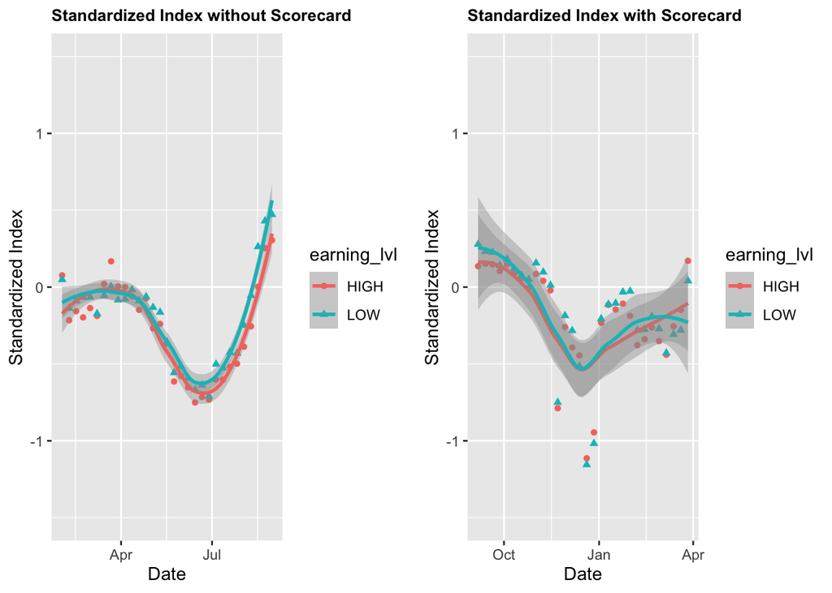

```r
# Compare scorecard's impact on standardized index between schools with high/low reported earnings
ggarrange(

  weekly_trend2 %>%
    filter(w_scorecard == 'NO') %>%
    group_by(begin_date, earning_lvl) %>%
    summarise(avg_index = mean(index_std)) %>%
    ggplot(aes(x = begin_date, y = avg_index, shape = earning_lvl, color = earning_lvl)) +
    xlab('Date') +
    ylab('Standardized Index') +
    geom_point() +
    ylim(-1.5, 1.5) +
    geom_smooth() +
    ggtitle('Standardized Index without Scorecard') +
    theme(plot.title = element_text(size = 10, face = "bold")),

  weekly_trend2 %>%
    filter(w_scorecard == 'YES') %>%
    group_by(begin_date, earning_lvl) %>%
    summarise(avg_index = mean(index_std)) %>%
    ggplot(aes(x = begin_date, y = avg_index, shape = earning_lvl, color = earning_lvl)) +
    xlab('Date') +
    ylab('Standardized Index') +
    geom_point() +
    ylim(-1.5, 1.5) +
    geom_smooth() +
    ggtitle('Standardized Index with Scorecard') +
    theme(plot.title = element_text(size = 10, face = "bold")),

  ncol = 2, nrow = 1
)
```

Judging by these couple plots, the standardized indexes of schools with low reported earnings seem to be higher than the ones with high reported earnings. Again, we are seeing that effect of in/out of research season on the standardized indexes. It seems that the gap between the standardized indexes of the two categories has been decreasing post the publishing of the scorecard.

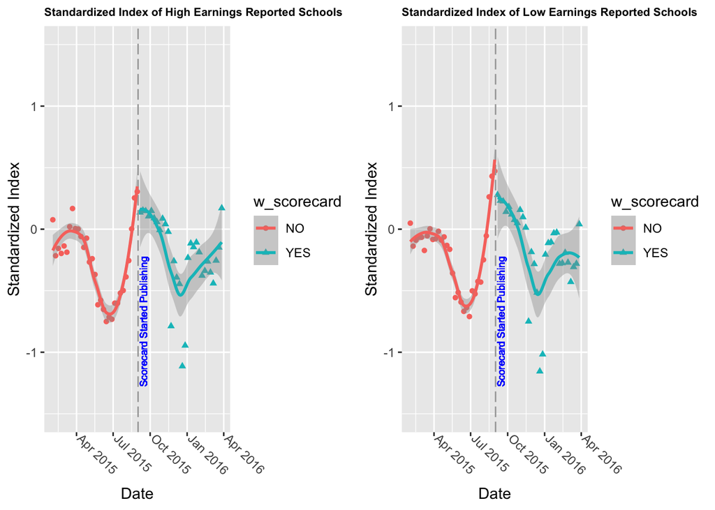

```r
# Compare school's reported earnings level's impact on standardized index before/after the scorecard is published
ggarrange(

  weekly_trend2 %>%
    filter(earning_lvl == 'HIGH') %>%
    group_by(begin_date, w_scorecard) %>%
    summarise(avg_index = mean(index_std)) %>%
    ggplot(aes(x = begin_date, y = avg_index, shape = w_scorecard, color = w_scorecard)) +
    xlab('Date') +
    ylab('Standardized Index') +
    ylim(-1.5, 1.5) +
    geom_point() +
    geom_vline(xintercept = as.Date('2015-09-01'), color = 'dark grey', linetype = 'longdash') +
    geom_text(aes(x = as.Date('2015-09-15'), label = 'Scorecard Started Publishing', y = -0.75), color = 'blue', angle = 90, size = 2.5) +
    theme(plot.title = element_text(size = 8, face = "bold"),
          axis.text.x = element_text(angle = -45, hjust = 0, vjust = 0)) +
    geom_smooth() +
    ggtitle('Standardized Index of High Earnings Reported Schools'),

  weekly_trend2 %>%
    filter(earning_lvl == 'LOW') %>%
    group_by(begin_date, w_scorecard) %>%
    summarise(avg_index = mean(index_std)) %>%
    ggplot(aes(x = begin_date, y = avg_index, shape = w_scorecard, color = w_scorecard)) +
    xlab('Date') +
    ylab('Standardized Index') +
    ylim(-1.5, 1.5) +
    geom_point() +
    geom_vline(xintercept = as.Date('2015-09-01'), color = 'dark grey', linetype = 'longdash') +
    geom_text(aes(x = as.Date('2015-09-15'), label = 'Scorecard Started Publishing', y = -0.75), color = 'blue', angle = 90, size = 2.5) +
    theme(plot.title = element_text(size = 8, face = "bold"),
          axis.text.x = element_text(angle = -45, hjust = 0, vjust = 0)) +
    geom_smooth() +
    ggtitle('Standardized Index of Low Earnings Reported Schools'),

  ncol = 2, nrow =1
)
```

## Regression

The decision of staying with a linear regression model, instead of using a polynomial model, is again due the observation that within (or outside) each school research season, the causal effect of the independent variables on the dependent variable is still linear.

### Multivariate Linear Regression Model

```r
# Build regression model
m <- lm(index_std ~ w_scorecard + earning_lvl + research_season + w_scorecard*earning_lvl, data = weekly_trend2)

# View coefficients
export_summs(m)
```

|  | Model 1 |
| --- | --- |
| (Intercept) | -0.38 *** |
|  | (0.01) |
| w_scorecardYES | 0.07 *** |
|  | (0.01) |
| earning_lvlLOW | 0.06 *** |
|  | (0.01) |
| research_seasonYES | 0.20 *** |
|  | (0.00) |
| w_scorecardYES:earning_lvlLOW | -0.02 ** |
|  | (0.01) |
| N | 107508 |
| R2 | 0.02 |
| *** p < 0.001; ** p < 0.01; * p < 0.05. |  |

```r
linearHypothesis(m, matchCoefs(m, c('w_scorecard', 'earning_lvl', 'research_season')))
```

```
## Linear hypothesis test
##
## Hypothesis:
## w_scorecardYES = 0
## w_scorecardYES:earning_lvlLOW = 0
##
## Model 1: restricted model
## Model 2: index_std ~ w_scorecard + earning_lvl + research_season + w_scorecard *
##     earning_lvl
##
##   Res.Df   RSS Df Sum of Sq      F    Pr(>F)
## 1 107505 52292
## 2 107503 52211  2    80.998 83.387 < 2.2e-16 ***
## ---
## Signif. codes:  0 '***' 0.001 '**' 0.01 '*' 0.05 '.' 0.1 ' ' 1
```

### Fixed Effect Model

Here we are looking at the fixed effect of “state” variable on the model, as it would have a causal effect on both levels of reported earning AND the standardized index.

```r
# Use fixed effect model to determine the effect of scorecard on school
fe <- lm(index_std ~ w_scorecard + earning_lvl + research_season + w_scorecard*earning_lvl + factor(state), data = weekly_trend2)

export_summs(fe)
```

|  | Model 1 |
| --- | --- |
| (Intercept) | -0.39 *** |
|  | (0.05) |
| w_scorecardYES | 0.07 *** |
|  | (0.01) |
| earning_lvlLOW | 0.05 *** |
|  | (0.01) |
| research_seasonYES | 0.20 *** |
|  | (0.00) |
| factor(state)AL | 0.01 |
|  | (0.05) |
| factor(state)AR | 0.11 * |
|  | (0.05) |
| factor(state)AZ | 0.03 |
|  | (0.05) |
| factor(state)CA | -0.06 |
|  | (0.05) |
| factor(state)CO | -0.03 |
|  | (0.05) |
| factor(state)CT | -0.04 |
|  | (0.05) |
| factor(state)DC | -0.04 |
|  | (0.05) |
| factor(state)DE | -0.04 |
|  | (0.06) |
| factor(state)FL | -0.04 |
|  | (0.05) |
| factor(state)GA | -0.07 |
|  | (0.05) |
| factor(state)GU | 0.15 |
|  | (0.10) |

[output cut: 89 more lines]

```r
linearHypothesis(fe, matchCoefs(fe, 'state'))
```

```
## Linear hypothesis test
##
## Hypothesis:
## factor(state)AL = 0
## factor(state)AR = 0
## factor(state)AZ = 0
## factor(state)CA = 0
## factor(state)CO = 0
## factor(state)CT = 0
## factor(state)DC = 0
## factor(state)DE = 0
## factor(state)FL = 0
## factor(state)GA = 0
## factor(state)GU = 0
## factor(state)HI = 0
## factor(state)IA = 0
## factor(state)ID = 0
## factor(state)IL = 0
## factor(state)IN = 0
## factor(state)KS = 0
## factor(state)KY = 0
## factor(state)LA = 0
## factor(state)MA = 0
## factor(state)MD = 0
## factor(state)ME = 0
## factor(state)MI = 0
## factor(state)MN = 0
## factor(state)MO = 0
## factor(state)MS = 0
## factor(state)MT = 0
## factor(state)NC = 0
## factor(state)ND = 0
## factor(state)NE = 0
## factor(state)NH = 0
## factor(state)NJ = 0
## factor(state)NM = 0
## factor(state)NV = 0
## factor(state)NY = 0
## factor(state)OH = 0
## factor(state)OK = 0
```

[output cut: 11 more lines]

```
## factor(state)VT = 0
## factor(state)WA = 0
## factor(state)WI = 0
## factor(state)WV = 0
## factor(state)WY = 0
##
## Model 1: restricted model
## Model 2: index_std ~ w_scorecard + earning_lvl + research_season + w_scorecard *
##     earning_lvl + factor(state)
##
##   Res.Df   RSS Df Sum of Sq      F    Pr(>F)
## 1 107503 52211
## 2 107450 51846 53    365.36 14.287 < 2.2e-16 ***
## ---
## Signif. codes:  0 '***' 0.001 '**' 0.01 '*' 0.05 '.' 0.1 ' ' 1
```

Interpretation:

- As the p-value being much smaller than the 5% significance level, we can reject the null that the dummy coefficients of different states are all jointly zero, as they’re statistically significant.

## Conclusion

Among colleges that predominantly grant bachelor’s degrees, our data is implying that schools with high reported earnings have benefited from the release of the College Scorecard and observed marginally higher interests relative to the ones with low reported earnings.